# 09.Reproductive_output

Elliott Schmidt

2024-05-17

# Scenario

Within this chapter developmental plasticity was explored within Acanthochromis polyacanthus that were collected from two different regions (i.e., low-latitude, Cairns, and high-latitude, Mackay). Fish were held in common garden experiments at 28.5 C. Reproductive meterics are only relevant to parental fish. Understanding potential differences in reproduction within fish from low- and high-latitude populations will provide basis of where juveniles are starting from.

# Load packages

```r
library(car)
library(tidyverse) # data manipulation
library(ggpubr) # figure arrangement
library(brms) # Bayesian models
library(StanHeaders)# needed to run Bayesian models
library(rstan) # needed to run Bayesian models
library(standist) # needs to be installed
library(bayesplot) # needed for MCMC diagnostics
library(DHARMa) # model validation
library(ggdist) # partial plots
library(tidybayes) # partial plots
library(broom.mixed) # model investigation
library(emmeans) # pairwise comparisons
library(rstanarm) # pairwise comparisons - need for emmeans
library(effectsize)
```

# Set working directory

```r
knitr::opts_knit$set(root.dir=working.dir)
```

# Import data

Note that when making the datasheet, each clutch was designated an ‘experimental_number’ that is associated with which experiment(s) clutches were involved in, therefore when importing the data, we will filter data to give us only clutches that were used in the relevant ‘developmental plasticity experiment’. We are also dropping one clutch that was found only when individuals hatched, meaning we don’t know the clutch size, or hatching success.

```r
egg_size <- read_delim("import_files/egg_size_data_2022_2023.txt",
    delim = "\t", escape_double = FALSE,
    trim_ws = TRUE)
```

```
## ──────────────────────────────────────────────────────── Delimiter: "\t" chr
## (9): DATA_EGGS_FOUND, COLOR, MALE, FEMALE, REGION, POPULATION, DATE_EGGS... dbl
## (9): CLUTCH_NUMBER, TEMPERATURE, TANK, ROOM, CLUTCH_ORDER, DAYS_IN_TREAT...
```

```r
clutch_data <- read_delim("import_files/clutch_data_2022_2023.txt",
    delim = "\t", escape_double = FALSE,
    trim_ws = TRUE) |>
  mutate(PROJECT_CODE = factor(PROJECT_CODE)) |>
  filter(PROJECT_CODE == "2"|
         PROJECT_CODE == "3"|
         PROJECT_CODE == "6"|
         PROJECT_CODE == "7") |>
  drop_na(EGG_COUNT)
```

# Data manipulation

```r
egg_size2 <- egg_size |>
  mutate(CLUTCH_NUMBER = as.factor(CLUTCH_NUMBER),
         MALE = factor(MALE),
         FEMALE = factor(FEMALE),
         REGION = factor(REGION),
         POPULATION = factor(POPULATION),
         CLUTCH_ORDER = factor(CLUTCH_ORDER),
         DATA_EGGS_FOUND = as.Date(DATA_EGGS_FOUND, format = "%d/%m/%Y")) |>
  select(-c("NOTES","...18")) |>
  group_by(CLUTCH_NUMBER) |>
  summarise(AVG_EGG_SIZE = mean(EGG_SIZE)) |>
  ungroup()

clutch_data2 <- clutch_data |>
  mutate(CLUTCH_NUMBER = as.factor(CLUTCH_NUMBER),
         MALE = factor(MALE),
         FEMALE = factor(FEMALE),
         REGION = factor(REGION),
         POPULATION = factor(POPULATION),
         CLUTCH_ORDER = factor(CLUTCH_ORDER),
         FEMALE_MASS = coalesce(FEMALE_MASS, MALE_MASS))

reprod.output <- clutch_data2 |>
  inner_join(egg_size2, by="CLUTCH_NUMBER") |>
  mutate(REPRODUCTIVE_OUTPUT = EGG_COUNT * AVG_EGG_SIZE)
```

# Exploratory data analysis

## Reproductive output

```r
p1 <- ggplot(reprod.output, aes(x =REGION, y =REPRODUCTIVE_OUTPUT, fill =REGION)) +
         geom_boxplot(color ="black") +
         theme_classic()
```

```r
p2 <- ggplot(reprod.output, aes(x =REGION, y =REPRODUCTIVE_OUTPUT, fill =REGION, color =REGION)) +
  geom_violin(alpha=.3, linewidth=1.5) +
  geom_dotplot(binaxis = "y", stackdir = 'center') +
  theme_classic()
```

```r
p3 <- ggplot(reprod.output, aes(x =REPRODUCTIVE_OUTPUT, fill =REGION)) +
  geom_dotplot(color ="black") +
  geom_density(alpha=0.6) +
  theme_classic()
```

```r
p4 <- ggplot(clutch_data2, aes(x =REGION, y =FEMALE_MASS, fill =REGION, color =REGION)) +
  geom_jitter(width=.05, size =3, alpha=.4) +
  theme_classic()
```

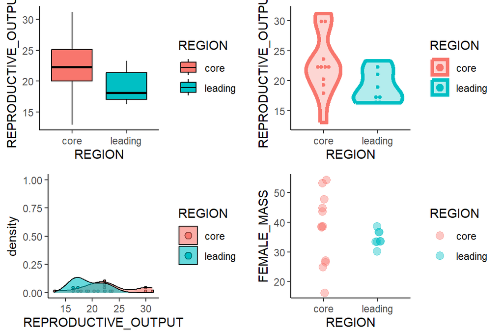

```r
ggarrange(p1,p2,p3,p4,
          nrow = 2,
          ncol =2)
```

# Fit model [random factors]

## Priors

```r
reprod.output |>
  group_by(REGION) |>
  summarise(mean(REPRODUCTIVE_OUTPUT),
            sd(REPRODUCTIVE_OUTPUT))
```

| REGION | mean(REPRODUCTIVE_OUTPUT) | sd(REPRODUCTIVE_OUTPUT) |
| --- | --- | --- |
| core | 22.83426 | 5.326547 |
| leading | 19.11620 | 2.750462 |

```r
reprod.output.priors <- prior(normal(21, 2.5), class ="Intercept")
```

## Models

### null

```r
f.model.null <- bf(REPRODUCTIVE_OUTPUT ~ 1,
                   family = gaussian())

model.null <- brm(f.model.null,
                  data =reprod.output,
                  prior =reprod.output.priors,
                  warmup = 500,
                  iter = 5000,
                  seed=123,
                  cores=2,
                  save_pars = save_pars(all=TRUE),
                  sample_prior = "yes",
                  chains = 2,
                  thin = 5,
                  control = list(adapt_delta=0.95))
```

### model1

```r
f.model1 <- bf(REPRODUCTIVE_OUTPUT ~ 1 + (1| FEMALE),
                   family = gaussian())

model1 <- brm(f.model1,
                  data =reprod.output,
                  prior =reprod.output.priors,
                  warmup = 500,
                  iter = 5000,
                  seed=123,
                  cores=2,
                  save_pars = save_pars(all=TRUE),
                  sample_prior = "yes",
                  chains = 2,
                  thin = 5,
                  control = list(adapt_delta=0.95))
```

### model2

```r
f.model2 <- bf(REPRODUCTIVE_OUTPUT ~ 1  + (1| FEMALE) + (1| POPULATION),
                   family = gaussian())

model2 <- brm(f.model2,
                  data =reprod.output,
                  prior =reprod.output.priors,
                  warmup = 500,
                  iter = 5000,
                  seed=123,
                  cores=2,
                  save_pars = save_pars(all=TRUE),
                  sample_prior = "yes",
                  chains = 2,
                  thin = 5,
                  control = list(adapt_delta=0.95))
```

### model3

```r
f.model3 <- bf(REPRODUCTIVE_OUTPUT ~ 1 + (1| FEMALE) + (1| CLUTCH_ORDER),
                   family = gaussian())

model3 <- brm(f.model3,
                  data =reprod.output,
                  prior =reprod.output.priors,
                  warmup = 500,
                  iter = 5000,
                  seed=123,
                  cores=2,
                  save_pars = save_pars(all=TRUE),
                  sample_prior = "yes",
                  chains = 2,
                  thin = 5,
                  control = list(adapt_delta=0.95))
```

### model4

```r
f.model4 <- bf(REPRODUCTIVE_OUTPUT ~ 1 + (1| FEMALE) + (1| POPULATION) + (1| CLUTCH_ORDER),
                   family = gaussian())

model4 <- brm(f.model4,
                  data =reprod.output,
                  prior =reprod.output.priors,
                  warmup = 500,
                  iter = 5000,
                  seed=123,
                  cores=2,
                  save_pars = save_pars(all=TRUE),
                  sample_prior = "yes",
                  chains = 2,
                  thin = 5,
                  control = list(adapt_delta=0.95))
```

## LOO

```r
loo(model.null, model1, model2, model3, model4)
```

```
## Output of model 'model.null':
##
## Computed from 1800 by 20 log-likelihood matrix.
##
##          Estimate  SE
## elpd_loo    -61.1 3.5
## p_loo         1.8 0.6
## looic       122.1 7.0
## ------
## MCSE of elpd_loo is 0.0.
## MCSE and ESS estimates assume MCMC draws (r_eff in [0.8, 1.1]).
##
## All Pareto k estimates are good (k < 0.69).
## See help('pareto-k-diagnostic') for details.
##
## Output of model 'model1':
##
## Computed from 1800 by 20 log-likelihood matrix.
##
##          Estimate  SE
## elpd_loo    -58.9 3.0
## p_loo         9.3 1.9
## looic       117.9 6.1
## ------
## MCSE of elpd_loo is NA.
## MCSE and ESS estimates assume MCMC draws (r_eff in [0.5, 1.0]).
##
## Pareto k diagnostic values:
##                           Count Pct.    Min. ESS
## (-Inf, 0.69]   (good)     11    55.0%   81
##    (0.69, 1]   (bad)       9    45.0%   <NA>
##     (1, Inf)   (very bad)  0     0.0%   <NA>
## See help('pareto-k-diagnostic') for details.
##
## Output of model 'model2':
##
## Computed from 1800 by 20 log-likelihood matrix.
##
##          Estimate  SE
## elpd_loo    -59.3 3.0
```

[output cut: 43 more lines]

```
##
## Pareto k diagnostic values:
##                           Count Pct.    Min. ESS
## (-Inf, 0.69]   (good)     11    55.0%   118
##    (0.69, 1]   (bad)       9    45.0%   <NA>
##     (1, Inf)   (very bad)  0     0.0%   <NA>
## See help('pareto-k-diagnostic') for details.
##
## Model comparisons:
##            elpd_diff se_diff
## model3      0.0       0.0
## model1     -0.3       1.2
## model2     -0.6       1.2
## model4     -1.1       0.5
## model.null -2.4       1.6
```

# fit model [fixed + random factors]

## priors

```r
reprod.output |>
  group_by(REGION) |>
  summarise(mean(REPRODUCTIVE_OUTPUT),
            sd(REPRODUCTIVE_OUTPUT))
```

| REGION | mean(REPRODUCTIVE_OUTPUT) | sd(REPRODUCTIVE_OUTPUT) |
| --- | --- | --- |
| core | 22.83426 | 5.326547 |
| leading | 19.11620 | 2.750462 |

```r
reprod.output.priors <- prior(normal(21, 2.5), class ="Intercept") +
  prior(normal(0, 3), class="b") +
  prior(student_t(3, 0, 5.33), class="sigma")
```

## Model3.1

### Model3.1

```r
f.model3.1 <- bf(REPRODUCTIVE_OUTPUT ~ 1 + REGION +
                   scale(FEMALE_MASS, center=TRUE, scale=TRUE) +
                   scale(DAYS_IN_TREATMENT, center=TRUE, scale=TRUE) +
                   (1| FEMALE) + (1| CLUTCH_ORDER),
                   family = gaussian())

model3.1 <- brm(f.model3.1,
                  data =reprod.output,
                  prior =reprod.output.priors,
                  warmup = 500,
                  iter = 5000,
                  seed=123,
                  cores=2,
                  save_pars = save_pars(all=TRUE),
                  sample_prior = "yes",
                  chains = 2,
                  thin = 10,
                  control = list(adapt_delta=0.95))
saveRDS(model3.1, file="./09.Reproductive_output_files/model3.1.RDS")
```

### Model validation [DHARMa]

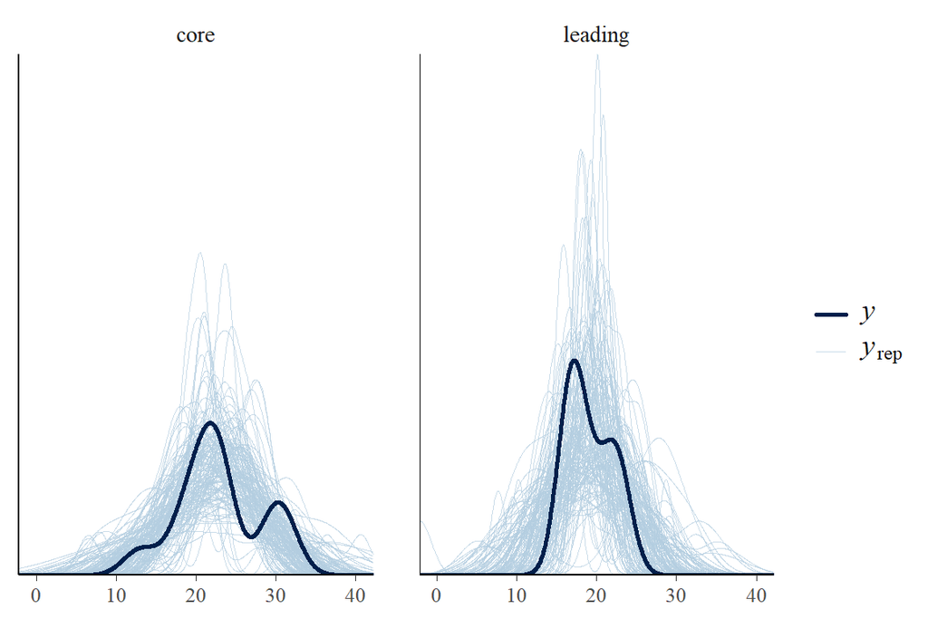

```r
pp_check(model3.1, type = 'dens_overlay_grouped', ndraws=150, group="REGION")
```

```
## qu = 0.25, log(sigma) = -3.736151 : outer Newton did not converge fully.
```

```
## qu = 0.5, log(sigma) = -3.229379 : outer Newton did not converge fully.
```

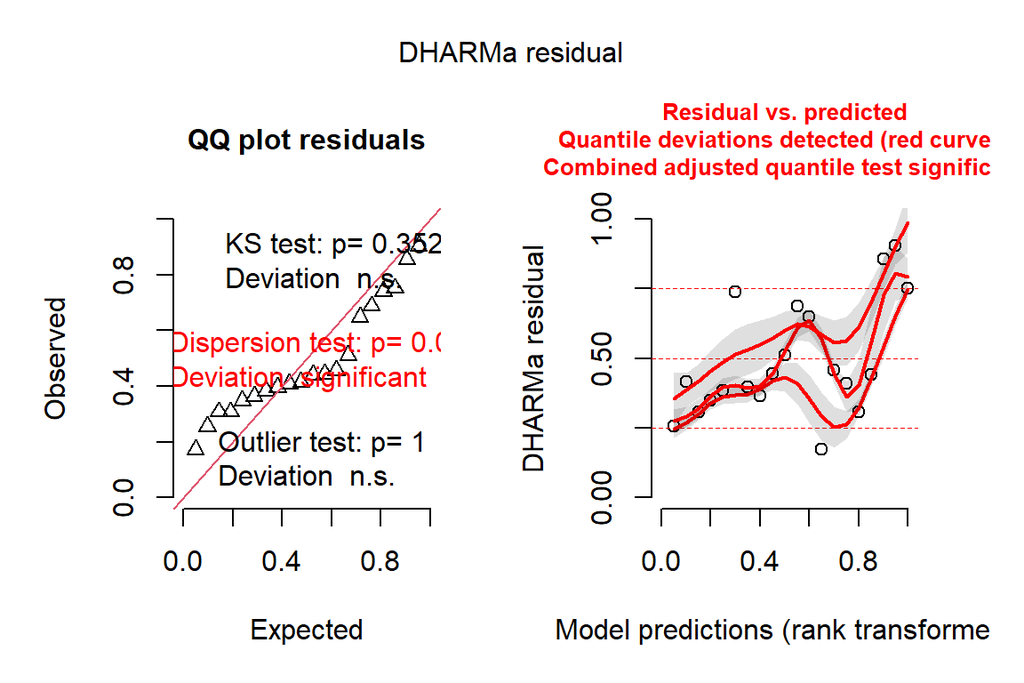

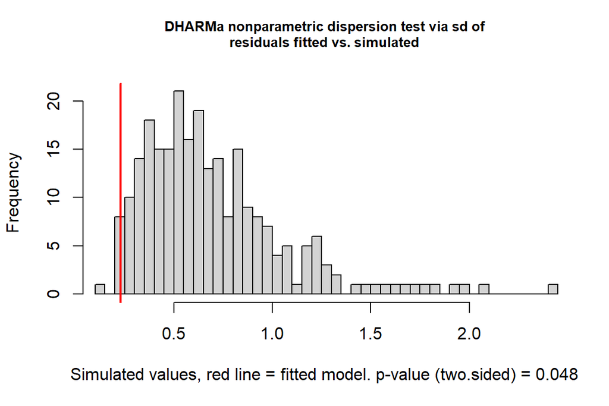

```
##
##  DHARMa nonparametric dispersion test via sd of residuals fitted vs.
##  simulated
##
## data:  simulationOutput
## dispersion = 0.32807, p-value = 0.048
## alternative hypothesis: two.sided
```

```r
preds <- posterior_predict(model3.1, ndraws=250, summary=FALSE)
model3.1_resids <- createDHARMa(simulatedResponse = t(preds),
                              observedResponse = reprod.output$REPRODUCTIVE_OUTPUT,
                              fittedPredictedResponse = apply(preds, 2, median),
                              integerResponse = 'student')
plot(model3.1_resids); testDispersion(model3.1_resids)
```

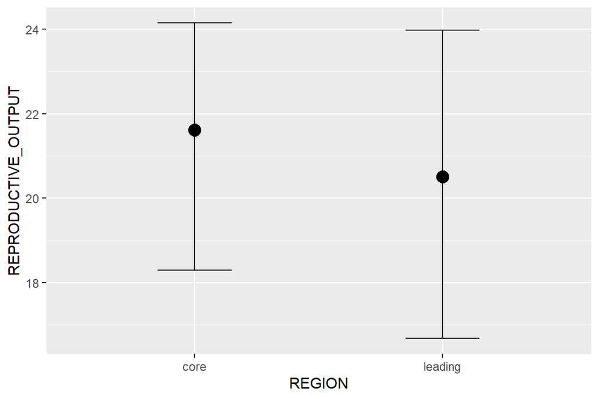

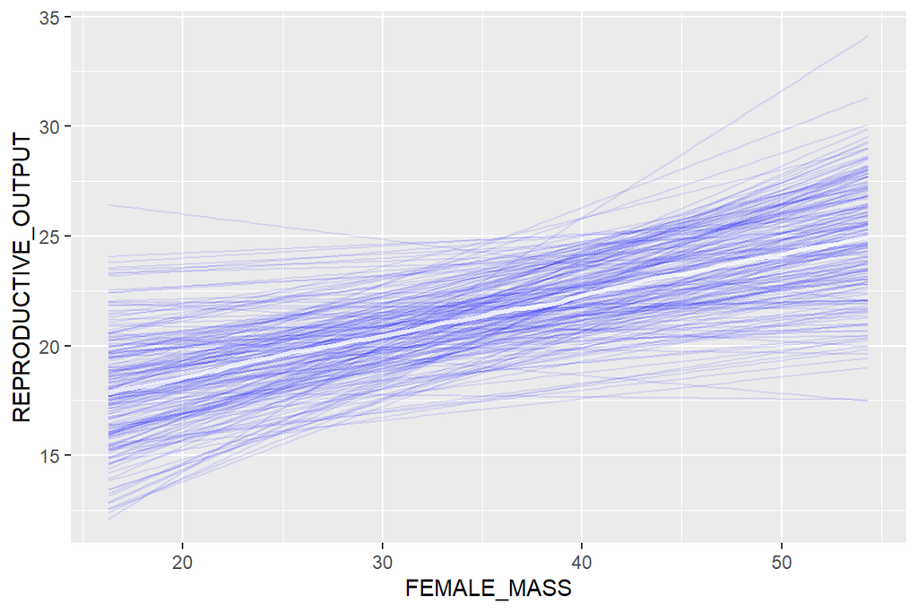

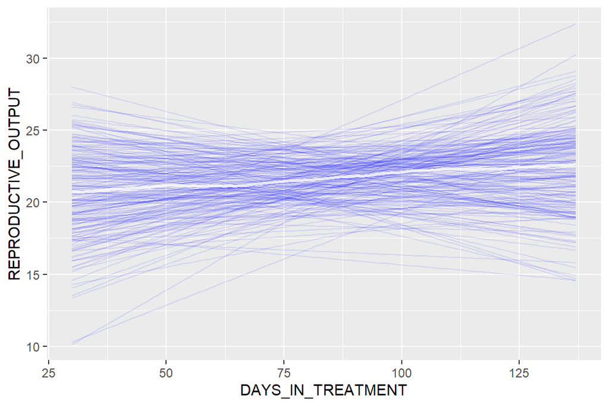

```r
model3.1 |> conditional_effects(spaghetti = TRUE, ndraws =200 )
```

### Model performance

```r
stan_trace(model3.1$fit)
```

```
## 'pars' not specified. Showing first 10 parameters by default.
```

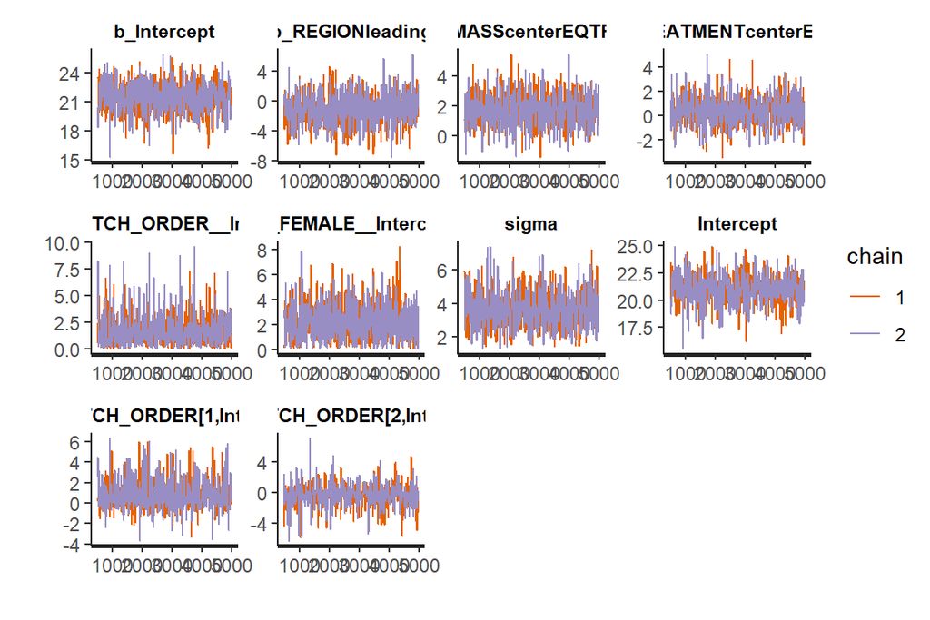

```r
stan_ac(model3.1$fit)
```

```
## 'pars' not specified. Showing first 10 parameters by default.
```

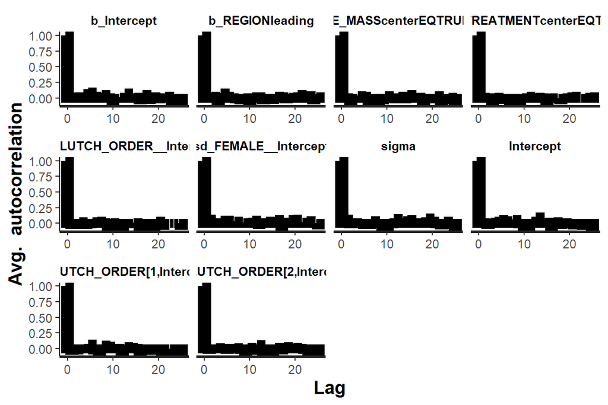

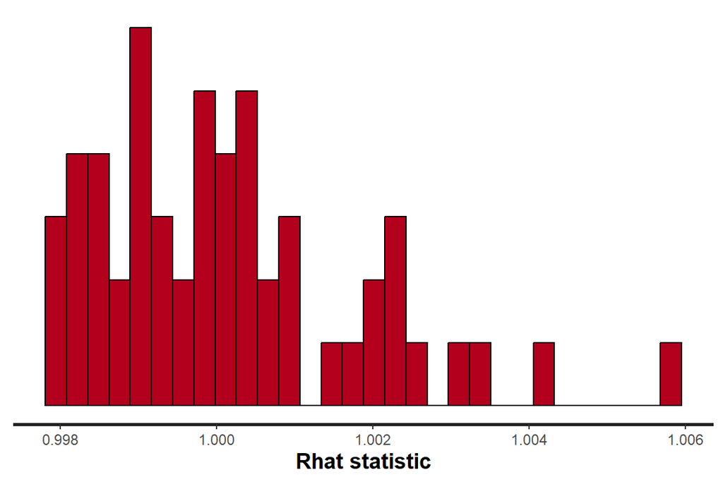

```r
stan_rhat(model3.1$fit)
```

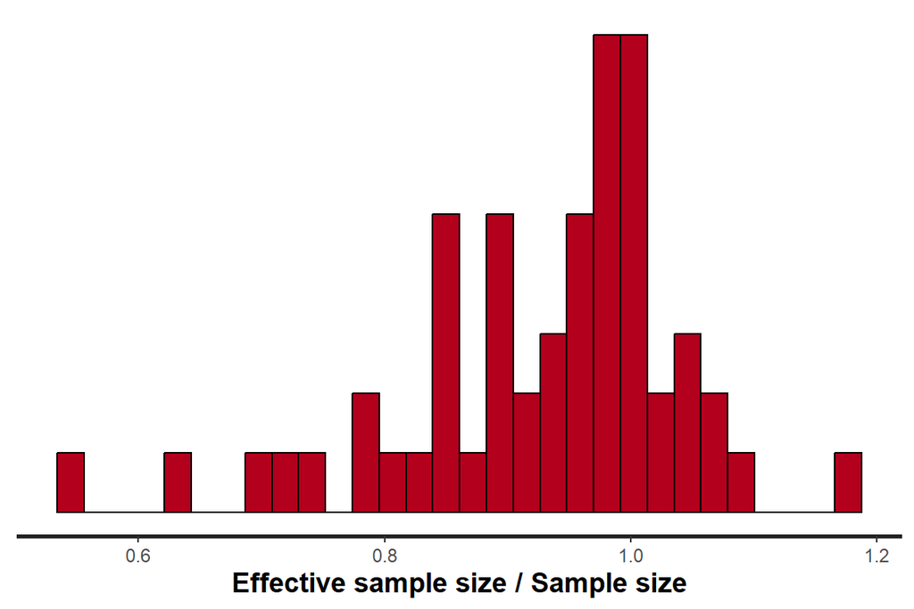

```r
stan_ess(model3.1$fit)
```

```r
stan_dens(model3.1$fit, separate_chains = TRUE)
```

```
## 'pars' not specified. Showing first 10 parameters by default.
```

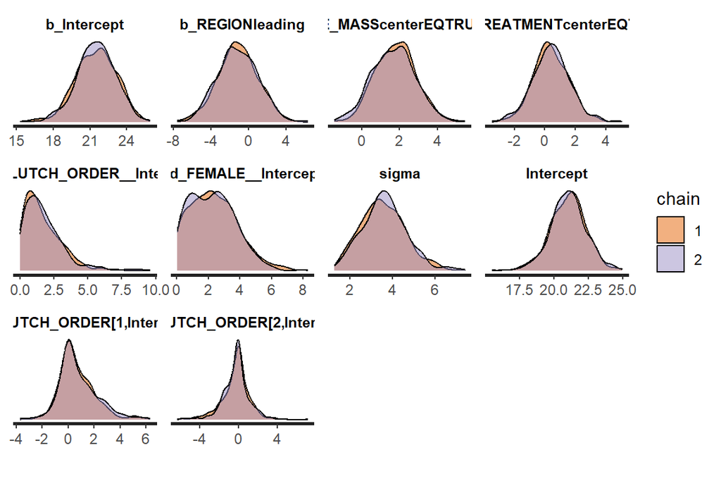

## Model3.1_gamma

### Model3.1_gamma

```r
reprod.output.priors <- prior(normal(21, 2.5), class ="Intercept") +
  prior(normal(0, 3), class="b")

f.model3.1_gamma <- bf(REPRODUCTIVE_OUTPUT ~ 1 + REGION +
                   scale(FEMALE_MASS, center=TRUE, scale=TRUE) +
                   scale(DAYS_IN_TREATMENT, center=TRUE, scale=TRUE) +
                   (1| FEMALE) + (1| CLUTCH_ORDER),
                   family = Gamma(link="log"))

model3.1_gamma <- brm(f.model3.1_gamma,
                  data =reprod.output,
                  prior =reprod.output.priors,
                  warmup = 500,
                  iter = 5000,
                  seed=123,
                  cores=2,
                  save_pars = save_pars(all=TRUE),
                  sample_prior = "yes",
                  chains = 2,
                  thin = 5,
                  control = list(adapt_delta=0.95))
saveRDS(model3.1_gamma, file="./09.Reproductive_output_files/model3.1_gamma.RDS")
```

### Model validation [DHARMa]

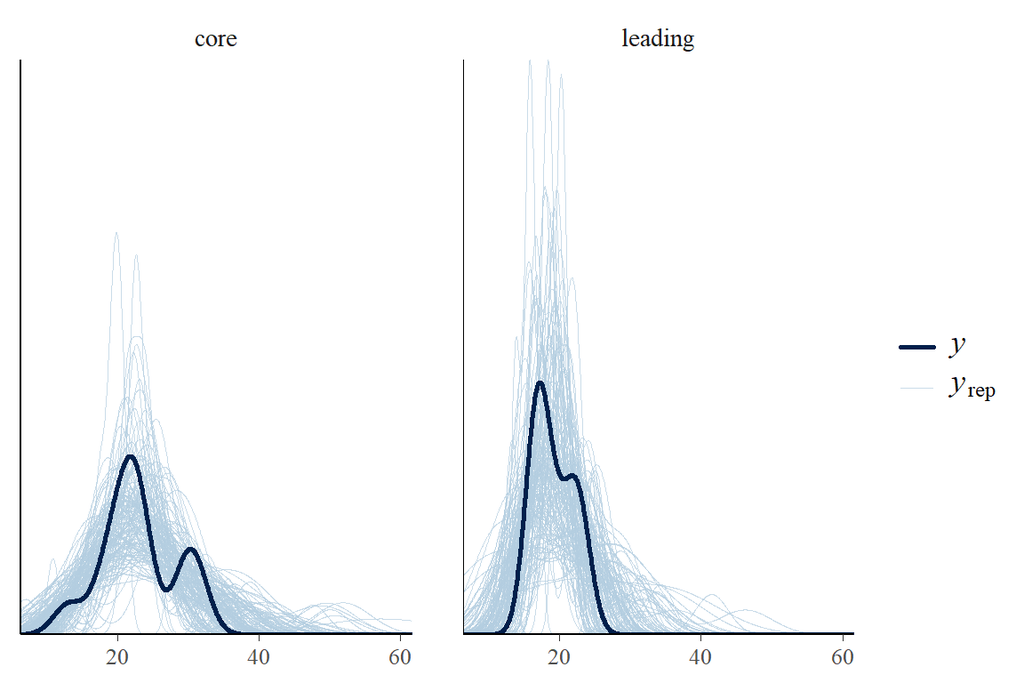

```r
pp_check(model3.1_gamma, type = 'dens_overlay_grouped', ndraws=150, group="REGION")
```

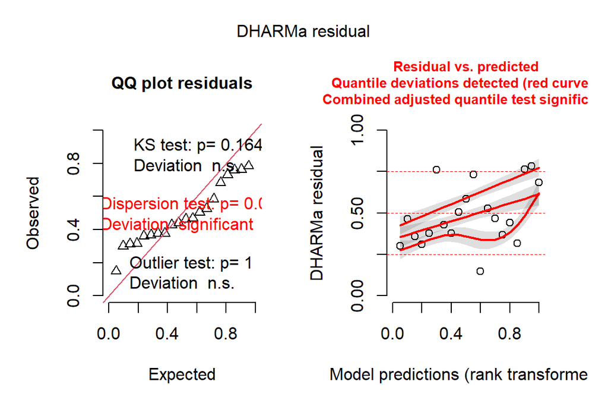

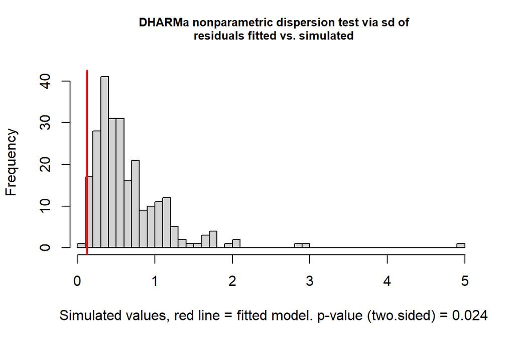

```
##
##  DHARMa nonparametric dispersion test via sd of residuals fitted vs.
##  simulated
##
## data:  simulationOutput
## dispersion = 0.18813, p-value = 0.024
## alternative hypothesis: two.sided
```

```r
preds <- posterior_predict(model3.1_gamma, ndraws=250, summary=FALSE)
model3.1_gamma_resids <- createDHARMa(simulatedResponse = t(preds),
                              observedResponse = reprod.output$REPRODUCTIVE_OUTPUT,
                              fittedPredictedResponse = apply(preds, 2, median),
                              integerResponse = 'student')
plot(model3.1_gamma_resids); testDispersion(model3.1_gamma_resids)
```

## Model3.1_log

```r
f.model3.1_log <- bf(REPRODUCTIVE_OUTPUT ~ 1 + REGION +
                   scale(FEMALE_MASS, center=TRUE, scale=TRUE) +
                   scale(DAYS_IN_TREATMENT, center=TRUE, scale=TRUE) +
                   (1| FEMALE) + (1| CLUTCH_ORDER),
                   family = gaussian(link="log"))

model3.1_log <- brm(f.model3.1_log,
                  data =reprod.output,
                  prior =reprod.output.priors,
                  warmup = 500,
                  iter = 5000,
                  seed=123,
                  cores=2,
                  save_pars = save_pars(all=TRUE),
                  sample_prior = "yes",
                  chains = 2,
                  thin = 5,
                  control = list(adapt_delta=0.95))
saveRDS(model3.1_log, file="./09.Reproductive_output_files/model3.1_log.RDS")
```

### Model validation [DHARMa]

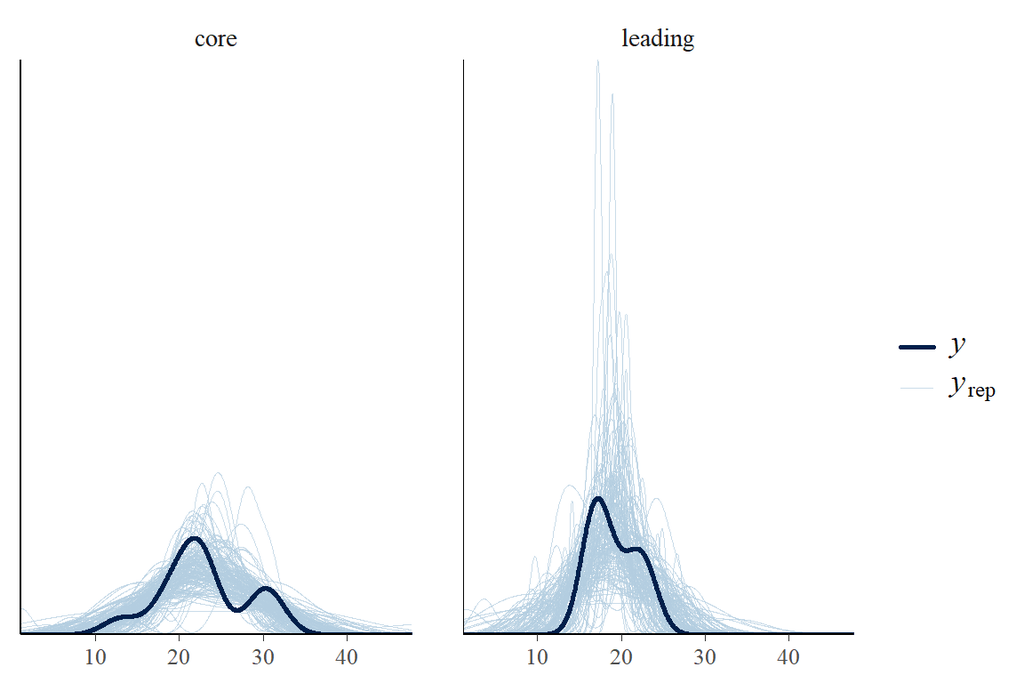

```r
pp_check(model3.1_log, type = 'dens_overlay_grouped', ndraws=150, group="REGION")
```

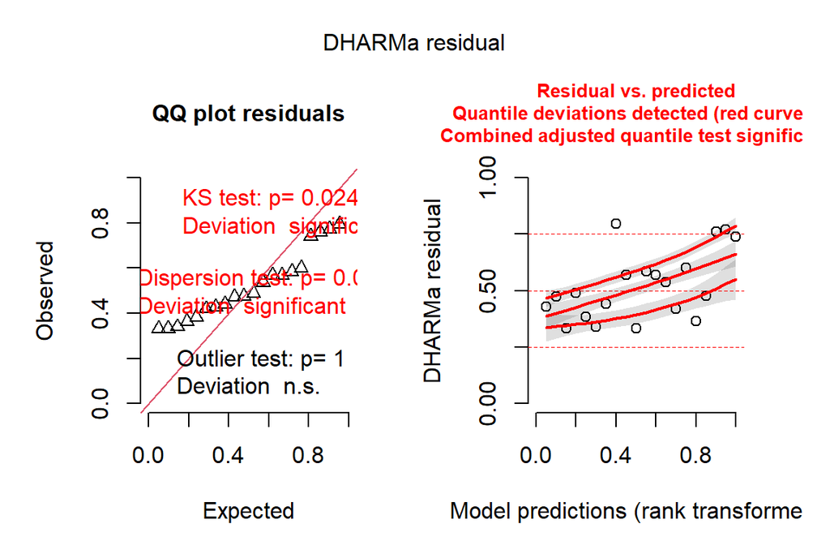

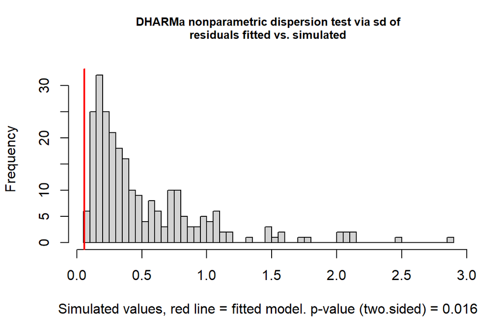

```
##
##  DHARMa nonparametric dispersion test via sd of residuals fitted vs.
##  simulated
##
## data:  simulationOutput
## dispersion = 0.11235, p-value = 0.016
## alternative hypothesis: two.sided
```

```r
preds <- posterior_predict(model3.1_log, ndraws=250, summary=FALSE)
model3.1_log_resids <- createDHARMa(simulatedResponse = t(preds),
                              observedResponse = reprod.output$REPRODUCTIVE_OUTPUT,
                              fittedPredictedResponse = apply(preds, 2, median),
                              integerResponse = 'student')
plot(model3.1_log_resids); testDispersion(model3.1_log_resids)
```

# Partial plots

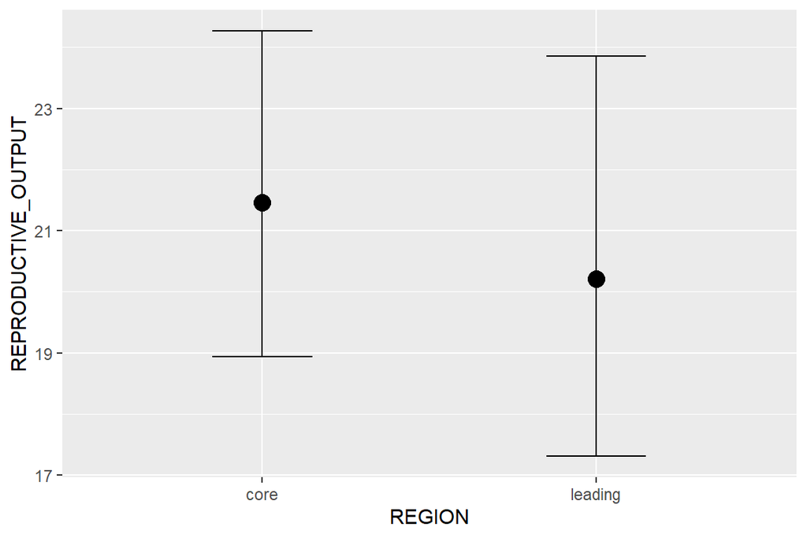

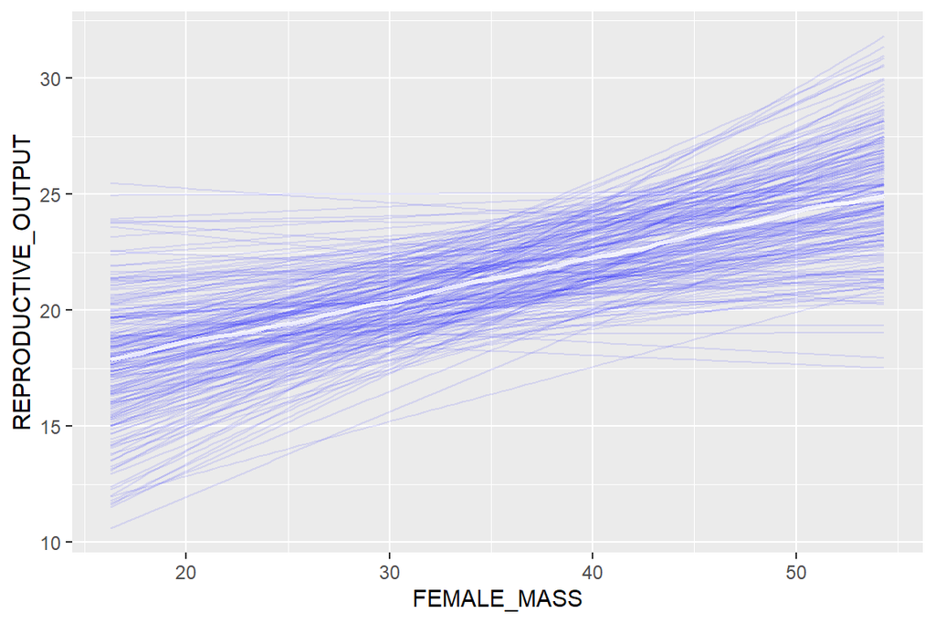

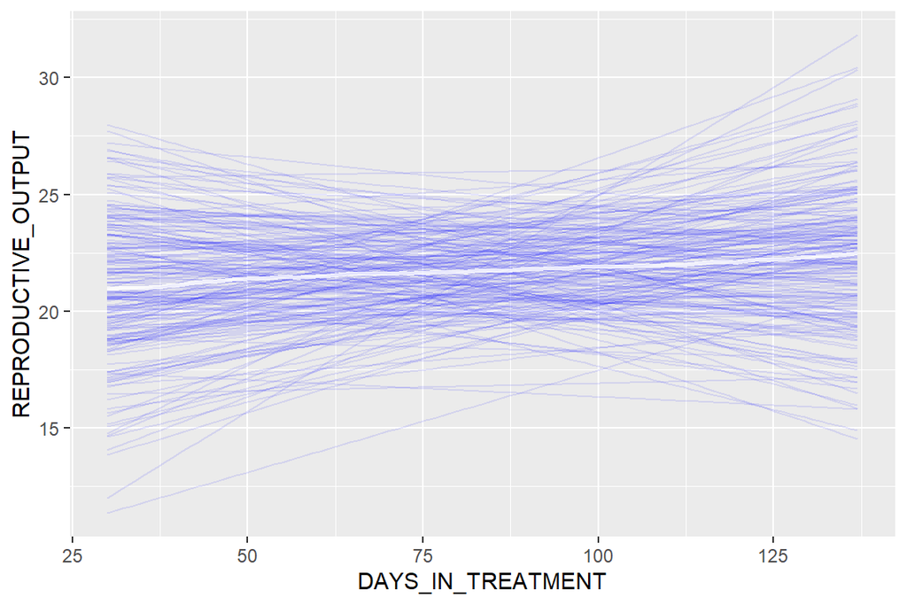

```r
model3.1 |>
  conditional_effects(spaghetti = TRUE, ndraws=200)
```

# Model investigation

## summary

```r
summary(model3.1)
```

```
##  Family: gaussian
##   Links: mu = identity; sigma = identity
## Formula: REPRODUCTIVE_OUTPUT ~ 1 + REGION + scale(FEMALE_MASS, center = TRUE, scale = TRUE) + scale(DAYS_IN_TREATMENT, center = TRUE, scale = TRUE) + (1 | FEMALE) + (1 | CLUTCH_ORDER)
##    Data: reprod.output (Number of observations: 20)
##   Draws: 2 chains, each with iter = 5000; warmup = 500; thin = 10;
##          total post-warmup draws = 900
##
## Group-Level Effects:
## ~CLUTCH_ORDER (Number of levels: 4)
##               Estimate Est.Error l-95% CI u-95% CI Rhat Bulk_ESS Tail_ESS
## sd(Intercept)     1.75      1.43     0.07     5.57 1.00      899      810
##
## ~FEMALE (Number of levels: 16)
##               Estimate Est.Error l-95% CI u-95% CI Rhat Bulk_ESS Tail_ESS
## sd(Intercept)     2.31      1.47     0.11     5.45 1.00      792      662
##
## Population-Level Effects:
##                                               Estimate Est.Error l-95% CI
## Intercept                                        21.49      1.60    18.22
## REGIONleading                                    -1.16      2.11    -5.25
## scaleFEMALE_MASScenterEQTRUEscaleEQTRUE           1.75      1.09    -0.39
## scaleDAYS_IN_TREATMENTcenterEQTRUEscaleEQTRUE     0.42      1.20    -1.95
##                                               u-95% CI Rhat Bulk_ESS Tail_ESS
## Intercept                                        24.38 1.00      881      562
## REGIONleading                                     2.90 1.00      852      783
## scaleFEMALE_MASScenterEQTRUEscaleEQTRUE           3.85 1.00      879      875
## scaleDAYS_IN_TREATMENTcenterEQTRUEscaleEQTRUE     2.90 1.00      874      857
##
## Family Specific Parameters:
##       Estimate Est.Error l-95% CI u-95% CI Rhat Bulk_ESS Tail_ESS
## sigma     3.59      1.05     1.73     5.87 1.00      782      756
##
## Draws were sampled using sampling(NUTS). For each parameter, Bulk_ESS
## and Tail_ESS are effective sample size measures, and Rhat is the potential
## scale reduction factor on split chains (at convergence, Rhat = 1).
```

## ANOVA

```r
pes_posterior <- eta_squared_posterior(model3.1,
  ndraws = 500, # how many samples from the PPD?
  partial = TRUE, # partial eta squared
  # type 3 SS
  ss_function = car::Anova, type = 3,
  verbose = FALSE
)
bayestestR::describe_posterior(pes_posterior, rope_ci=0.89)
```

|  | Parameter | Median | CI | CI_low | CI_high | pd | ROPE_CI | ROPE_low | ROPE_high | ROPE_Percentage |
| --- | --- | --- | --- | --- | --- | --- | --- | --- | --- | --- |
| 1 | REGION | 0.04835792 | 0.95 | 0.0002135085 | 0.3278426 | 1 | 0.89 | -0.1 | 0.1 | 0.7274775 |
| 3 | scale(FEMALE_MASS, center = TRUE, scale = TRUE) | 0.13793757 | 0.95 | 0.0010743474 | 0.4923085 | 1 | 0.89 | -0.1 | 0.1 | 0.3806306 |
| 2 | scale(DAYS_IN_TREATMENT, center = TRUE, scale = TRUE) | 0.02967309 | 0.95 | 0.0001962691 | 0.3060791 | 1 | 0.89 | -0.1 | 0.1 | 0.8490991 |

## HDCI

```r
model3.1 |> bayes_R2(summary = FALSE) |> median_hdci(.width = 0.89)
```

| y | ymin | ymax | .width | .point | .interval |
| --- | --- | --- | --- | --- | --- |
| 0.519495 | 0.2520642 | 0.8570725 | 0.89 | median | hdci |

## tidyMCMC

```r
tidyMCMC(model3.1, estimate.method='median', conf.int=TRUE, conf.method='HPDinterval', conf.level = 0.89)
```

| term | estimate | std.error | conf.low | conf.high |
| --- | --- | --- | --- | --- |
| b_Intercept | 2.153298e+01 | 1.6013183 | 18.929443263 | 23.8746954 |
| b_REGIONleading | -1.186016e+00 | 2.1120952 | -4.140654655 | 2.4768197 |
| b_scaleFEMALE_MASScenterEQTRUEscaleEQTRUE | 1.756757e+00 | 1.0911590 | 0.169382775 | 3.5674486 |
| b_scaleDAYS_IN_TREATMENTcenterEQTRUEscaleEQTRUE | 3.781257e-01 | 1.2020320 | -1.352750390 | 2.3314387 |
| sd_CLUTCH_ORDER__Intercept | 1.413530e+00 | 1.4324224 | 0.005439479 | 3.4341231 |
| sd_FEMALE__Intercept | 2.207172e+00 | 1.4668900 | 0.048117426 | 4.1445697 |
| sigma | 3.533260e+00 | 1.0540154 | 1.744283417 | 5.0531775 |
| Intercept | 2.106912e+01 | 1.3162626 | 19.239499019 | 23.3209581 |
| r_CLUTCH_ORDER[1,Intercept] | 4.042765e-01 | 1.4401558 | -1.292959496 | 2.9050622 |
| r_CLUTCH_ORDER[2,Intercept] | -1.275471e-01 | 1.4240812 | -2.400076147 | 1.8856503 |

[output cut: 44 more lines]

## gather draws

```r
#model3.1 |> get_variables()
model3.1 |> gather_draws(`b_.*|sigma`, regex =TRUE) |>
  median_hdci(.width=0.89)
```

| .variable | .value | .lower | .upper | .width | .point | .interval |
| --- | --- | --- | --- | --- | --- | --- |
| b_Intercept | 21.5329847 | 19.044763478 | 24.042487 | 0.89 | median | hdci |
| b_REGIONleading | -1.1860157 | -4.274595416 | 2.343850 | 0.89 | median | hdci |
| b_scaleDAYS_IN_TREATMENTcenterEQTRUEscaleEQTRUE | 0.3781257 | -1.352750382 | 2.331439 | 0.89 | median | hdci |
| b_scaleFEMALE_MASScenterEQTRUEscaleEQTRUE | 1.7567572 | -0.004896034 | 3.418705 | 0.89 | median | hdci |
| sigma | 3.5332601 | 1.744283416 | 5.053178 | 0.89 | median | hdci |

## bayesplot

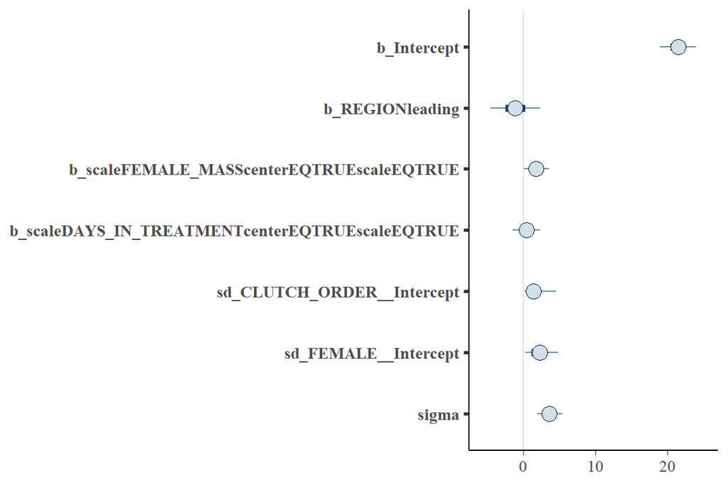

```r
model3.1 |> mcmc_plot(type='intervals')
```

## emmeans - pariwise

```r
model3.1 |> emmeans(pairwise ~ REGION, type="response") |> summary()
```

```
## $emmeans
##  REGION  emmean lower.HPD upper.HPD
##  core      21.5      18.3      24.4
##  leading   20.4      16.5      23.7
##
## Point estimate displayed: median
## HPD interval probability: 0.95
##
## $contrasts
##  contrast       estimate lower.HPD upper.HPD
##  core - leading     1.19     -2.61      5.48
##
## Point estimate displayed: median
## HPD interval probability: 0.95
```

## probabilities

```r
mtsqst <- model3.1 |> emmeans(pairwise ~ REGION)
mtsqrt2 <- mtsqst$contrasts |> gather_emmeans_draws()
mtsqrt2 %>% group_by(contrast) %>% dplyr::summarise(Prob = sum(.value>0)/n())
```

| contrast | Prob |
| --- | --- |
| core - leading | 0.7077778 |

# Summary figure

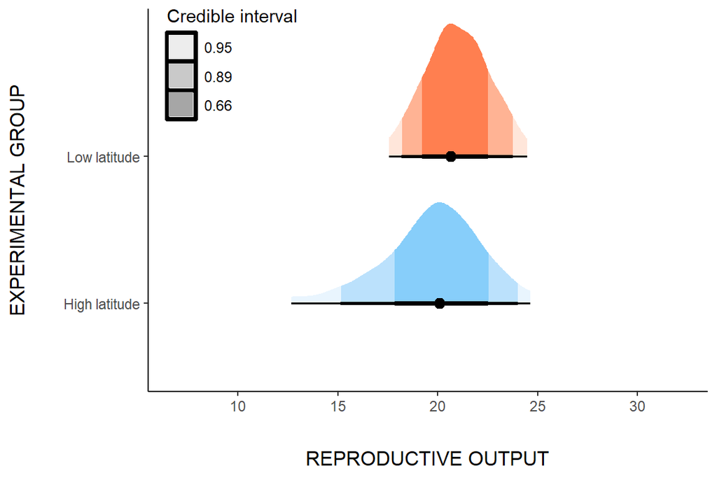

```r
var <- get_variables(model3.1)
var1 <- get_variables(model3.1)[c(1:2)]

int_draws_spread <- model3.1 |> spread_draws(!!!syms(var1))

int_draws_spread2 <- int_draws_spread |>
  gather_draws(b_Intercept, b_REGIONleading) |>
  left_join(int_draws_spread, by = c(".chain",".iteration",".draw"))


int_draws <- int_draws_spread2 |>
  mutate(RCore = case_when(`.variable` == 'b_Intercept' ~
                             `.value`,
                           `.variable` != 'b_Intercept' ~
                             `.value` + b_Intercept),

         RLeading = case_when(`.variable` == 'b_Intercept' ~
                           `.value` + b_REGIONleading,
                         `.variable` == 'b_REGIONleading' ~
                           `.value` + b_Intercept + `b_REGIONleading`))

int_draws_plotting <- int_draws |>
  pivot_longer(cols = starts_with("R"),
               names_to = "REGION",
               values_to = "REPRODUCTIVE_OUTPUT") |>
  transmute(LATITUDE = case_when(`.variable` == "b_Intercept" ~ "Low latitude",
                                 `.variable` == "b_REGIONleading" ~ "High latitude"),
            REPRODUCTIVE_OUTPUT = REPRODUCTIVE_OUTPUT,
            LATITUDE_B = LATITUDE,
            chain = `.chain`,
            iteration = `.iteration`,
            draw_n = `.draw`)

reprod.output.plot <- int_draws_plotting |>
  ggplot(aes(x=LATITUDE, y=REPRODUCTIVE_OUTPUT)) +
  #geom_hline(yintercept = 0, linetype="dashed", linewidth=1, color="grey58", alpha=0.8) +
  stat_halfeye(aes(fill = LATITUDE, fill_ramp = after_stat(level)),
               point_interval = mode_hdci,
               .width = c(.66, .89, .95)) +
  scale_fill_ramp_discrete(na.translate=FALSE,
                           labels =c("0.95","0.89","0.66"),
                           name = "Credible interval") +
  scale_fill_manual(values = c("lightskyblue","coral"))+
  #scale_y_continuous(limits=c(0,2), breaks = seq(0,2, .5))+
  ylab("REPRODUCTIVE OUTPUT") + xlab("EXPERIMENTAL GROUP") +
  scale_x_discrete(labels = c("Low latitude" = paste0("Low latitude"),
                              "High latitude" = paste0("High latitude"))) +
  #annotate("text", x=6.8,y=1.4, label = paste0(round(mean(growth3$MASS), 2)," (mm)"), color="grey58") +
  coord_flip() +
  theme_classic() +
  guides(fill = "none") +
  theme(legend.position = c(.15,.86),
        axis.title.y = element_text(margin = margin(r =0.3, unit = "in"), size = 12),
        axis.title.x = element_text(margin = margin(t = 0.3, unit="in"), size =12),
        legend.key = element_rect(color="black", size=1.25),
        legend.background = element_rect(fill = alpha("blue", 0))); reprod.output.plot
```